# Practical ML

#### Overview

This document decribes how I operated to build my prediction model for the prediction assignment. I describe each logical step in a dedicated section.

#### Step 1: Data filtering

I first cleaned both training and test set from the following:

- Columns with NA and empty values (no data is useless information)
- Rows with “new window” equal to 1 (sort of “summary” of previous time window)
- All time stamp information (no need to analyze time evolution in this problem in my opinion and anyway I don’t know how to do it)
- Column X

The reason for cleaning the data is just to have it loaded and handled a bit faster in my R scripts.

#### Step 2: Set the seed, have a look at the data

I created a training and a test set from the training data file. My goal at this stage was to produce some plots and get insights about the structure of the data.

I created the train and test set with the usual code:

```
# Seed -> always the same sampling in my script
set.seed(12345)
# p = 0.75, I simply chose the course "default"
inTrain  <- createDataPartition(y=filteredTrainingData$classe, p=0.75, list=FALSE)
training <- userData[inTrain,]
testing <- userData[-inTrain,]
```

My first idea was to produce feature plots, hoping to spot features separating the different classes. However I gave it up quite soon: I tried some variables combinations but it always resulted in one class point covering up all the figure, with no clear separation.

Therefore, I took another approach and decided to:

1. Plot each feature vs class in a separate plot (boxplot + jitter)
2. Further filter the data by person (“user_name”)

The reason of choice 1 being to overcome the readability problem I had with the feature plots. As for choice 2 I made the hypothesis that the same exercise class performed by persons with different physical attributes would result in different measurement ranges for a given feature.

Example plots are:

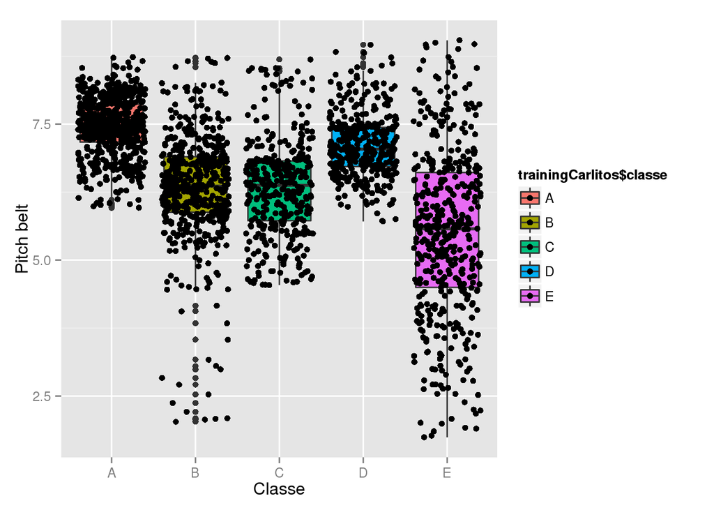

```r
# trainingCarlitos and trainingAdelmo contain the filtered data for the users Carlitos and Adelmo.
p1 = qplot(trainingCarlitos$classe, trainingCarlitos$pitch_belt, fill=trainingCarlitos$classe, geom=c("boxplot","jitter"), ylab="Pitch belt", xlab="Classe")

p2 = qplot(trainingAdelmo$classe, trainingAdelmo$pitch_belt, fill=trainingAdelmo$classe, geom=c("boxplot","jitter"), ylab="Pitch belt", xlab="Classe")

plot(p1)
```

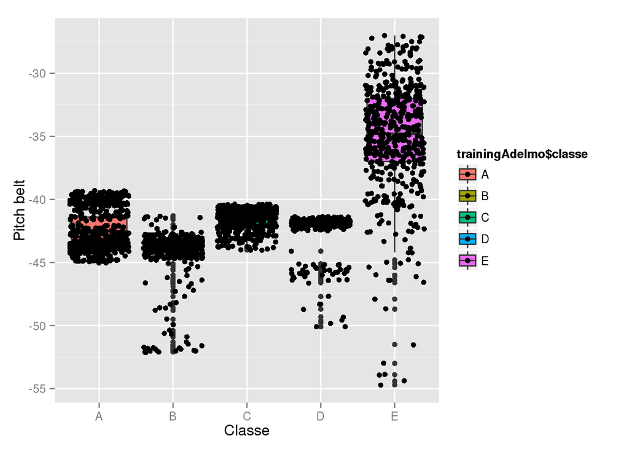

```r
plot(p2)
```

Comparing the data in the two plots, indeed the scale is different. Given this fact, I decided to train 6 different predictors, one for each person, rather than having the algorithm figuring out for itself that the person name was the first variable to use to make the decision.

This choice I made is motivated by the fact that the test data we want to predict in the assignement is collected with the very same users. If the goal was to have a more general predictor (i.e. predicting also unseen users data) or do predictions with a much larger number of users this would not be a valid approach.

#### Step 3: Model selection and training - first attempt

NOTE: in the following I describe what I did to train the model for the user “Adelmo”. Thus the numerical results reported here refer to the subset of data for Adlemo. For the other users I proceeded anlogously with the corresponding user data.

To train each of the models, I decided to use 5-fold cross validation. Training parameter control can be achieved in caret with the `trainControl` function. In my case I only set the number of folds I wanted to have (5) and left the remaining parameters to their default:

```
trParam <- trainControl(method="cv",number=5,verboseIter=FALSE)
```

The object trParam can then be passed to the `train` function to set the training parameters. As for the model type, I tried random forests (`method="rf"` for the `train` function) and Gradient Boosting Machine (`method="gbm"` for the `train` function). I got pretty decent results in both cases, but I selected gbm for my final predictors (no specific reason).

As a first test, I trained the model using all the available features (remember I filtered out “useless” variables first) and had a look at the results (confusionMatrix) for the training data prediction.

```r
# Here "training" contains all the features and class for the training set of user Adelmo
model <- train(classe ~ ., data=training,method="gbm",trControl=trParam,verbose=FALSE)

predictionTrain = predict(model, training)

confusionMatrix(predictionTrain, training$class)
```

```
## Confusion Matrix and Statistics
##
##           Reference
## Prediction   A   B   C   D   E
##          A 856   0   0   0   0
##          B   0 571   0   0   0
##          C   0   0 552   0   0
##          D   0   0   0 381   0
##          E   0   0   0   0 498
##
## Overall Statistics
##
##                Accuracy : 1
##                  95% CI : (0.9987, 1)
##     No Information Rate : 0.2995
##     P-Value [Acc > NIR] : < 2.2e-16
##
##                   Kappa : 1
##  Mcnemar's Test P-Value : NA
##
## Statistics by Class:
##
##                      Class: A Class: B Class: C Class: D Class: E
## Sensitivity            1.0000   1.0000   1.0000   1.0000   1.0000
## Specificity            1.0000   1.0000   1.0000   1.0000   1.0000
## Pos Pred Value         1.0000   1.0000   1.0000   1.0000   1.0000
## Neg Pred Value         1.0000   1.0000   1.0000   1.0000   1.0000
## Prevalence             0.2995   0.1998   0.1931   0.1333   0.1742
## Detection Rate         0.2995   0.1998   0.1931   0.1333   0.1742
## Detection Prevalence   0.2995   0.1998   0.1931   0.1333   0.1742
## Balanced Accuracy      1.0000   1.0000   1.0000   1.0000   1.0000
```

With which I get a (scary) 100% accuracy on the training set. Training such a model took roughly a minute and a half on my laptop. The test set prediction accuracy is:

```r
# Here "testing" contains all the features and class for the testing set of user Adelmo
predictionTest = predict(model, testing)

confusionMatrix(predictionTest, testing$class)
```

```
## Confusion Matrix and Statistics
##
##           Reference
## Prediction   A   B   C   D   E
##          A 285   0   0   0   0
##          B   0 190   1   0   0
##          C   0   0 181   2   0
##          D   0   0   2 124   0
##          E   0   0   0   0 166
##
## Overall Statistics
##
##                Accuracy : 0.9947
##                  95% CI : (0.9878, 0.9983)
##     No Information Rate : 0.2997
##     P-Value [Acc > NIR] : < 2.2e-16
##
##                   Kappa : 0.9933
##  Mcnemar's Test P-Value : NA
##
## Statistics by Class:
##
##                      Class: A Class: B Class: C Class: D Class: E
## Sensitivity            1.0000   1.0000   0.9837   0.9841   1.0000
## Specificity            1.0000   0.9987   0.9974   0.9976   1.0000
## Pos Pred Value         1.0000   0.9948   0.9891   0.9841   1.0000
## Neg Pred Value         1.0000   1.0000   0.9961   0.9976   1.0000
## Prevalence             0.2997   0.1998   0.1935   0.1325   0.1746
## Detection Rate         0.2997   0.1998   0.1903   0.1304   0.1746
## Detection Prevalence   0.2997   0.2008   0.1924   0.1325   0.1746
## Balanced Accuracy      1.0000   0.9993   0.9905   0.9909   1.0000
```

Since the prediction accuracy is excellent I could have gone this way (use all the features) to train the remaining models (other users). However: where’s the fun then? I spent more time producing the plots than playing with the predictor. Thus I decided to try producing each model using as few features as possible while getting decent results.

#### Step 4: Final models training

To select the features to use for each model I iterated these steps:

1. Look at the boxplots, select a feature that show a “neat” separation of one or more classes from the rest
2. Add that feature to the current features list
3. Train the model using the features (as described in section 3) - use at least 2
4. Check the prediction accuracy on the training set
5. Repeat until satisfied (accuracy 95% confidence interval > 0.97)
6. Final validation with testing data

So for example for point 1 in my iterative procedure “pitch_belt” looks an interesting feature (again “Adelmo” results shown):

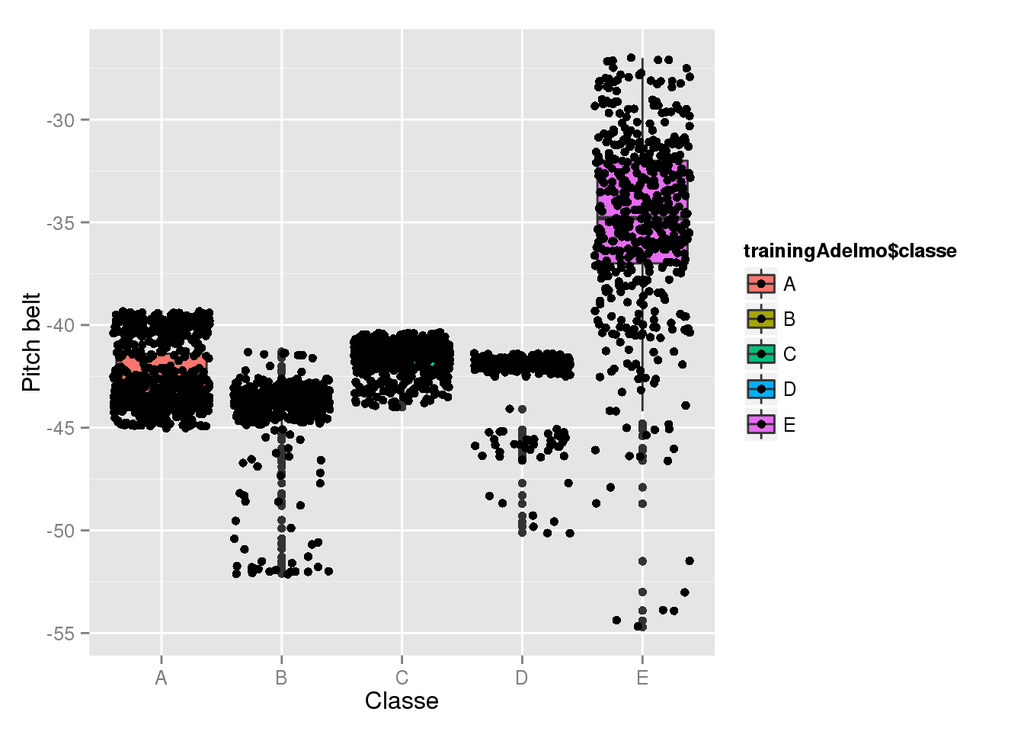

It is “interesting” because it already isolates class E and partly distinguishes between C or D vs A or B (imagine a threshold of -42.5 separating the 2 pairs of classes for many data points).

For the user Adelmo, a model based on “pitch_belt” and “roll_belt” results in (training not shown, see Section 3):

```r
model <- train(classe ~ ., data=training,method="gbm",trControl=trParam,verbose=FALSE)

predictionTrain = predict(model, training)
```

```r
confusionMatrix(predictionTrain, training$class)
```

```
## Confusion Matrix and Statistics
##
##           Reference
## Prediction   A   B   C   D   E
##          A 764  22  12   3   6
##          B  40 517  27   1   1
##          C  25  28 457  12   0
##          D  27   4  56 365   4
##          E   0   0   0   0 487
##
## Overall Statistics
##
##                Accuracy : 0.9062
##                  95% CI : (0.8949, 0.9167)
##     No Information Rate : 0.2995
##     P-Value [Acc > NIR] : < 2.2e-16
##
##                   Kappa : 0.881
##  Mcnemar's Test P-Value : NA
##
## Statistics by Class:
##
##                      Class: A Class: B Class: C Class: D Class: E
## Sensitivity            0.8925   0.9054   0.8279   0.9580   0.9779
## Specificity            0.9785   0.9698   0.9718   0.9633   1.0000
## Pos Pred Value         0.9467   0.8823   0.8755   0.8004   1.0000
## Neg Pred Value         0.9551   0.9762   0.9593   0.9933   0.9954
## Prevalence             0.2995   0.1998   0.1931   0.1333   0.1742
## Detection Rate         0.2673   0.1809   0.1599   0.1277   0.1704
## Detection Prevalence   0.2824   0.2050   0.1826   0.1596   0.1704
## Balanced Accuracy      0.9355   0.9376   0.8999   0.9606   0.9890
```

Which is not bad (and takes less than 10 seconds to train). Given these results I would now search (looking at the boxplots) for a feature better separating A-B-C, since most misclassification errors happen there.

NOTE: I know that looking this way at the boxplots is not really a guarantee. I could choose a feature that separates classes for points that are already well classified, but well, it’s almost Christmas, I work, and I do not have much time to spend fighting with R to figure out how to analyze and plot more complex interactions.

My final model for the user Adelmo uses the following features:

- pitch_belt
- roll_belt
- total_accel_belt
- magnet_belt_x
- magnet_belt_z
- yaw_belt

The prediction on Adelmo test set using my final model:

```r
predictionTest = predict(model, testing)

confusionMatrix(predictionTest, testing$class)
```

```
## Confusion Matrix and Statistics
##
##           Reference
## Prediction   A   B   C   D   E
##          A 277   2   2   0   0
##          B   0 186   3   1   0
##          C   6   2 178   6   0
##          D   2   0   1 119   0
##          E   0   0   0   0 166
##
## Overall Statistics
##
##                Accuracy : 0.9737
##                  95% CI : (0.9614, 0.9829)
##     No Information Rate : 0.2997
##     P-Value [Acc > NIR] : < 2.2e-16
##
##                   Kappa : 0.9665
##  Mcnemar's Test P-Value : NA
##
## Statistics by Class:
##
##                      Class: A Class: B Class: C Class: D Class: E
## Sensitivity            0.9719   0.9789   0.9674   0.9444   1.0000
## Specificity            0.9940   0.9947   0.9817   0.9964   1.0000
## Pos Pred Value         0.9858   0.9789   0.9271   0.9754   1.0000
## Neg Pred Value         0.9881   0.9947   0.9921   0.9916   1.0000
## Prevalence             0.2997   0.1998   0.1935   0.1325   0.1746
## Detection Rate         0.2913   0.1956   0.1872   0.1251   0.1746
## Detection Prevalence   0.2955   0.1998   0.2019   0.1283   0.1746
## Balanced Accuracy      0.9830   0.9868   0.9746   0.9704   1.0000
```

I also tried to use the features for Adelmo classifier to train classifier for other users generally obtaing poor results.

#### Other models

For the sake of completeness, I report here the features that I used for the remaining models.

Carlitos:

- roll_belt
- roll_forearm
- pitch_forearm
- pitch_dumbbell
- accel_dumbbell_z
- magnet_belt_y
- pitch_arm

Charles:

- roll_belt
- roll_forearm
- yaw_dumbbell
- accel_dumbbell_z
- magnet_dumbbell_z

Eurico:

- roll_belt
- magnet_arm_z
- magnet_dumbbell_x
- magnet_forearm_z
- pitch_dumbbell
- pitch_forearm

Jeremy:

- roll_belt
- roll_forearm
- yaw_forearm
- magnet_dumbbell_x
- magnet_dumbbell_y
- magnet_dumbbell_z
- magnet_belt_x
- magnet_belt_z

Pedro:

- roll_belt
- pitch_belt
- pitch_forearm
- roll_forearm
- accel_forearm_y
- roll_arm
- magnet_arm_z

#### Conclusion

With my models I got a pretty decent accuracy (18/20) in the assignement cases. I could have probably done 20/20 using all the features each time, but it was not my goal. I simply wanted to play a bit with the package and try to keep the models as small as possible. I am totally satisfied with my result.